# Basic concepts of Statistics: Inference

18 October 2018

## Outline

## Outline

Measuring the dependence among variables:

- Covariance and Correlation
- (simple) Linear model

Inference:

- What is about
- Hypothesis testing
- Confidence intervals
- Simulation

## Before we start (in R)

```r
#clean the memory
rm (list=ls ())

# We customize the output of our graphs a little bit
par.old=par ()
par (cex.main=1.5, lwd=2, col="darkgrey", pch=20, cex=3)
# par (par.old)
palette (c ("#FF0000", "#00A08A", "#FFCC00", "#445577", "#45abff"))

# customize the output of knitr
knitr :: opts_chunk$set (fig.align="center")#, fig.width=6, fig.height=6)
```

## The Age vs Reaction Time Dataset

The reaction time of these subjects was tested by having them grab a meter stick after it was released by the tester. The number of centimeters that the meter stick dropped before being caught is a direct measure of the person’s response time.

The values of `Age` are in years. The `Gender` is coded as `F` for female and `M` for male. The values of `Reaction.Time` are in centimeters.

(data are fictitious)

To read the data

```r
data(reaction,package = "flip")
# or download it from: https://github.com/livioivil/flip/tree/master/data
# str (reaction)
```

We plot the data

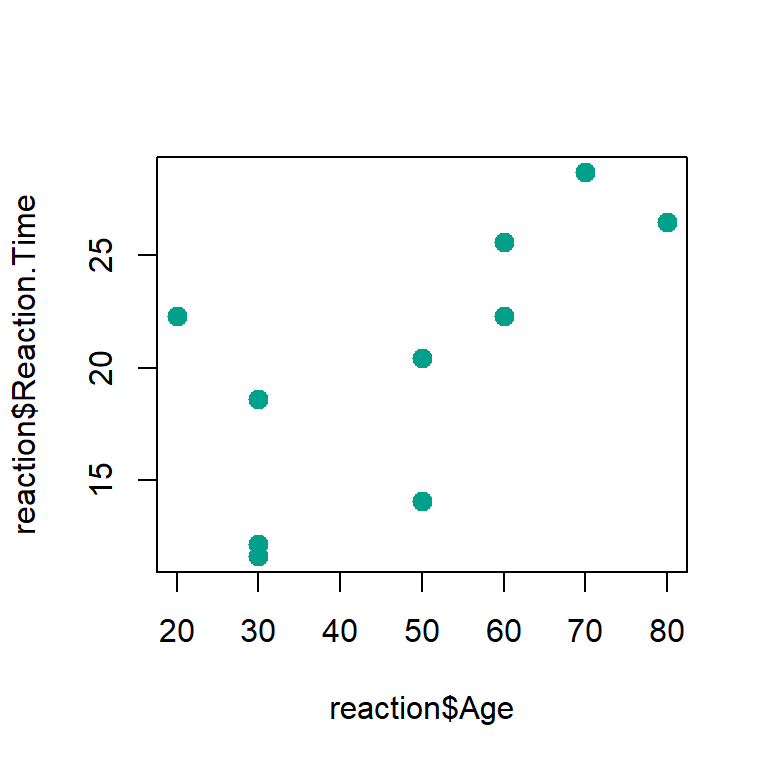

```r
plot(x=reaction$Age,y=reaction$Reaction.Time,pch=20,col=2,cex=2)
```

## Measures of Dependence and the Simple linear model

## Measuring the dependence

we define:

- \(X=Age\)
- \(Y=Reaction.Time\)

We review some famous index to measure the (linear) dependence among two variables

## Covariance and Variance

**Covariance** between \(X\) and \(Y\):

\(\sigma_{xy}=\frac{\sum_{i=1} ^ n (x_i- \bar{x}) (y_i- \bar{y} )}{n}\)

- values between \(- \infty\) and \(\infty\)
- \(\sigma_{xy} \approx 0\): there is no dependency between \(X\) and \(Y\)
- \(\sigma_{xy} >> (<<) 0\): there is a strong positive (negative) dependency between \(X\) and \(Y\)

**Variance** of \(X\) (= covariance between \(X\) and \(X\)):

\(\sigma_{xx}=\sigma_{x} ^ 2= \frac{\sum_{i=1} ^ n (x_i- \bar{x}) ^ 2}{n}\)

**Standard Deviation** of \(X\):

\(\sigma_{xx}=\sqrt{\sigma_{xx}}=\sigma_{x}\)

## Correlation

With the Covariance it is difficult to understand when the relationship between \(X\) and \(Y\) is strong / weak. We note that

\(- \sigma_{x} \sigma_{y} \leq \sigma_{xy} \leq \sigma_{x} \sigma_{y}\) is quivalent to \(-1 \leq \frac{\sigma_{xy}}{\sigma_{x} \sigma_{y}} \leq 1\)

**Correlation** between \(X\) and \(Y\):

\(\rho_{xy}=\frac{\sigma{xy}}{\sigma_{x} \sigma_{y}} = \frac{\sum_{i=1} ^ n (x_i- \bar{x}) (y_i- \bar{y})}{\sqrt{\sum_{i=1} ^ n (x_i- \bar{ x}) ^ 2} \sqrt{\sum_{i=1} ^ n (y_i- \bar{y}) ^ 2}}\)

- values between \(-1\) and \(1\)
- \(\rho_{xy} \approx 0\): there is no dependency between \(X\) and \(Y\)
- \(\rho_{xy} \approx 1 (-1)\): there is a strong positive (negative) dependency between \(X\) and \(Y\)

## Linear Trend, the least squares method

We describe the relationship between  
`Reaction.Time` and `Age` with a straight line.

\(Reaction.Time \approx \beta_0 + \beta_1 Age\)  
\(Y=\beta_0 + \beta_1X\)

Let’s draw a line ‘in the middle’ of the data.

The **least-squares estimator**

We look for the one that passes more ‘in the middle’, the one that minimizes the sum of the squares of the residues:

\(\hat{\beta}_0\) and \(\hat{\beta}_1\) such that  
\(\sum_{i=1} ^ n (y_i - (\hat{\beta}_0 + \hat{\beta}_1x_i )) ^ 2\) is minimum.

Estimates:

- Angular coefficient: \(\hat{\beta}_1=\frac{\sigma_{xy}}{\sigma_{xx}}=\rho_{xy}\frac{\sigma_{y}}{\sigma_{x}}=\frac{\sum_{i=1}^n(x_i- \bar{x})(y_i-\bar{y})}{\sum_{i=1}^n (x_i-\bar{x})^2}=\) 0.2064719
- Intercept: \(\hat{\beta}_0=\bar{y}-\hat{\beta}_1\bar{x}=\) 10.3013483
- Response (estimated \(y\)): \(\hat{y}_i=\hat{\beta}_0 + \hat{\beta}_1x_i\)
- Residuals (from the estimated response): \(y_i - (\hat{\beta}_0 + \hat{\beta}_1 x_i)=y_i- \hat{y}_i\)

and therefore the least squares are the sum of the squared residuals: \(\sum_{i=1} ^ n (y_i- \hat{\beta}_0 + \hat{\beta}_1x_i) ^ 2=\sum_{i=1} ^ n (y_i- \hat{y}_i ) ^ 2\)

A graphical representation:

```r
model=lm(Reaction.Time~Age,data=reaction)
coefficients(model)
```

```
## (Intercept)         Age
##  10.3013483   0.2064719
```

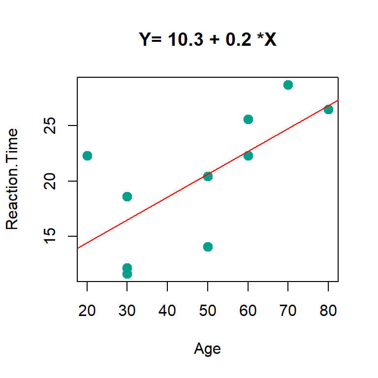

```r
plot(x=reaction$Age,y=reaction$Reaction.Time,pch=20,col=2,cex=2,xlab="Age",ylab="Reaction.Time")
coeff=round(coefficients(model),1)
title(paste("Y=",coeff[1],"+",coeff[2],"*X"))
abline(model,col=1)
```

## Interpretation of the coefficients

- \(\beta_0\) indicates the value of \(y\) when \(x=0\) (where the line intersects the ordinate axis).
- \(\beta_1\) indicates how much \(y\) grows as a unit of \(x\) grows
  - If \(\beta_1=0\) there is no relation between \(x\) and \(y\).\(Y\)is constant (horizontal ), knowing\(x\)does not change the estimate of \(y\)
  - If \(\beta_1> (<) 0\) the relation between \(x\) and \(y\) is positive (negative). When \(X\) passes from \(x\) a \(x + 1\) the estimate of \(Y\) changes from \(\hat{y}\) to \(\hat{y} + \hat{\beta}_1\)

## Permutation approach to Hypothesis Testing

## Some remarks

Let’s note that all the measures above does not make any assumptions on the random process that generate them.

Let’s assume that \(Y\) - and possibly \(X\) - is not fix, while it is generated by a random variable.

The question: **Is there a relationship between \(Y\) and \(X\)**?

We estimated \(\hat{\beta}_1=\) 0.2064719

but the **true value** \(\beta_1\) is really different from 0 (i.e. no relationship)?  
Otherwise, is the distance to 0 is due to the random sampling?

- **Null Hypothesis** \(H_0: \ \beta_1=0\) (the **true** \(\beta_1\), not its estimate \(\hat{\beta}_1\)!). There is no relationship between \(X\) and \(Y\).
- **Alternative Hypothesis** \(H_1: \ \beta_1 >0\) The relationship is positive.

Other possible specifications of \(H_1: \ \beta_1< 0\) and, more commonly, \(H_1: \ \beta_1 \neq 0\).

## Permutation tests - in a nutshell

As a toy example, let use a sub-set of the data:

```
##   Age Gender Reaction.Time
## 9  20      F         22.27
## 4  60      F         22.27
## 7  30      M         12.15
```

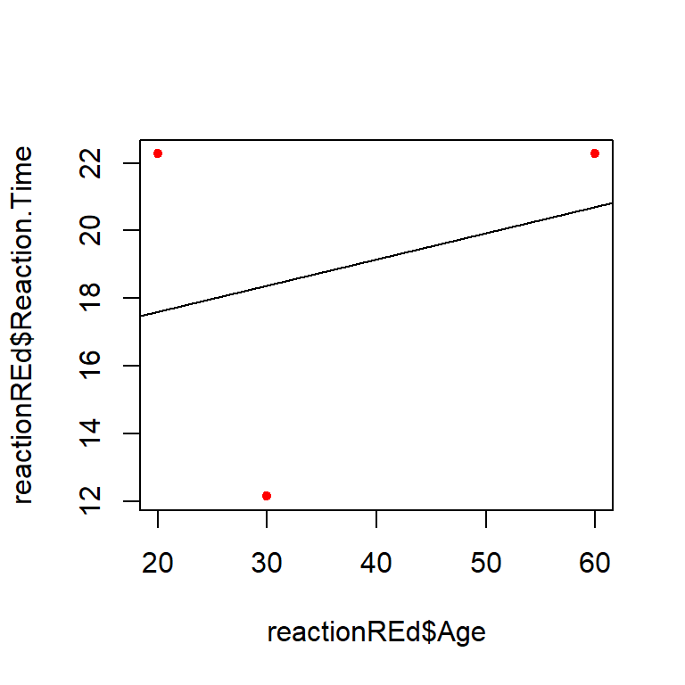

- *If \(H_0\)* is true: there is no linear relationship between \(X\) and \(Y\)
- Therefore, the trend observed on the data is due to chance.
- Any other match of \(x_i\) and \(y_i\) was equally likely to occur
- I can generate the datasets of other hypothetical experiments by exchanging the order of the observations in \(Y\).
- How many equally likely datasets could I get with\(X\) and \(Y\)observed? \(3 * 2 * 1=3!=6\) possible datasets.

Remark: Here we only assume that \(y\) is a random variable. The only assumption here is the exchangeability of the observations: the joint density \(f(y_1,\ldots,y_n)\) does not change when the ordering of \(y_1,\ldots,y_n\) is changed.

## All potential datasets

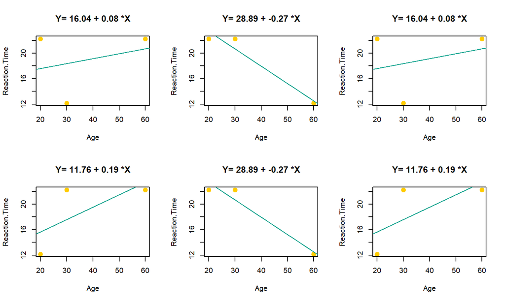

## Random permutations

In our data set, if we apply the same principle…

How many permutations of the vector \(y_1,\ldots,y_n\) are possible? \(n!=\) 3.6288^{6}.

big, perhaps not too big … but what happen with, for example, \(n=20\)? We got \(20!=\) 2.432902^{18}. This is too big, definitely!

We calculate a smaller (but sufficiently large) \(B\) of random permutations.

here some example

**`Age` vs a permutations of `Reaction.Time`**

[figure not shown]

We repeat 10^{4} times and we look at the histogram of the \(\hat{\beta}_1\)

```r
# beta_1 estimated on the observed data:
beta1=coefficients(lm(Reaction.Time~Age,data=reaction))[2]

# function that permutes the y values and calculates the coeff beta_1
my.beta.perm <- function(Y,X){
  model=lm(sample(Y)~X)
  coefficients(model)[2]
}

#replicate it B-1 times
beta.perm= replicate(B,my.beta.perm(reaction$Reaction.Time, reaction$Age ))
```

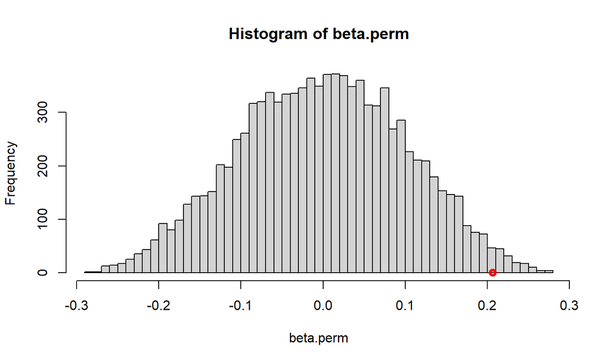

## How likely WAS \(\hat{\beta}_1 ^{obs}\)?

(before the experiment!)

How likely was it to get a \(\leq \hat{\beta}_1 ^{obs}\) value among the many possible values of \(\hat{\beta}_1 ^{*b}\) (obtained by permuting data)?

Remarks:

- \(\hat{\beta}_1 ^{* b}< \hat{\beta}_1 ^{obs}\) (closer to 0): less evidence against \(H_1\) than \(\hat{\beta}_1 ^{obs}\)
- \(\hat{\beta}_1 ^{* b} \geq \hat{\beta}_1 ^{obs}\): equal or more evidence towards \(H_1\) than \(\hat{\beta}_1 ^{obs}\)

## Calculation of the p-value

Over B=10^{4} permutations we got 9852 times a \(\hat{\beta}_1 ^{* b} \leq \hat{\beta}_1 ^{obs}\).

The p-value (significance) is \(p=\frac{\# (\hat{\beta}_1 ^{* b} \geq \hat{\beta}_1 ^{obs})}{B + 1} =\) 0.015

## Interpretation

Neyman-Pearson’s approach has made common the use of a significance threshold for example \(\alpha=.05\) (or \(=. 01\)). When \(p \leq \alpha\) rejects the hypothesis that there is no relationship between X and Y (\(H_0\)). If so, we are inclined to think that \(H_1\) is true (there is a positive relationship).

- Type I error: False Positive  
  the true hypo is \(H_0\) (null correlation), BUT we accept \(H_1\) (correlation is positive)
- Type II error: False Negative  
  the true hypo is \(H_1\) (positive correlation), BUT we do not reject \(H_0\) (null correlation)

**Type I error control**

We want to guarantee not to get false relationships (a few false positives), better to be conservative. To make this, we want to bound the probability to make a false discovery:

\(P (p-value \leq \alpha | H_0) \leq \alpha\)

We built a machinery that in the long run (many replicates of the experiment) finds false correlations with probability \(\alpha\) (e.g. \(0.05=5\%\)).

## We make it in `flip`

```r
library(flip)

(res=flip(Reaction.Time~Age,data=reaction,
          tail=1,perms = 10000))
```

```
##
##               Test  Stat tail p-value
## Reaction.Time    t 2.633    >  0.0166
```

```r
## compare also with
# flip(Reaction.Time~Age,data=reaction,tail=1,statTest = "cor")
# flip(Reaction.Time~Age,data=reaction,tail=1,statTest = "coeff")
```

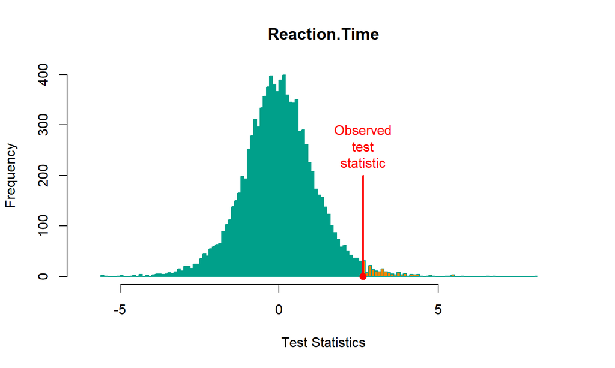

```r
plot(res)
```

## Composite alternatives (bilateral)

The hypothesis \(H_1: \ \beta_1 >0\) (the relation is positive) must be justified with a priori knowledge.

More frequently, the Alternative hypothesis is appropriate: \(H_1: \ \beta_1 \neq 0\) (there is a relationship, I do not assume the direction)

I consider anomalous coefficients estimated as very small but also very large (‘far from 0’). The p-value is \(p=\frac{\#(|\hat{\beta}_1^{*b} | \geq|\hat{\beta}_1^{obs}|)}{B+1}=\) 0.0321

In `flip`:

```r
library(flip)
(res=flip(Reaction.Time~Age,data=reaction,tail=0,perms=5000))
```

```
##
##               Test  Stat tail p-value
## Reaction.Time    t 2.633   ><  0.0360
```

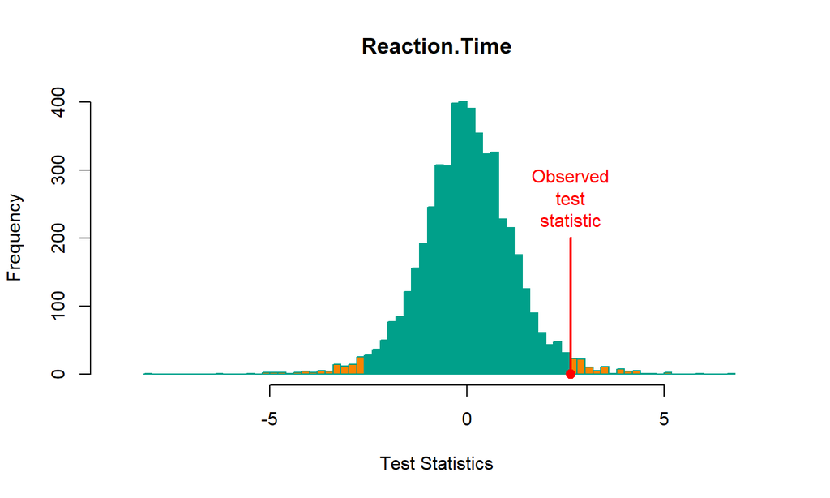

```r
plot(res)
```

## Some remarks

- Do not be confused with bootstrap methods. The former are extractions without reintegration, the latter with. The former have almost optimal properties and have (almost always) an exact control of the first type errors.
- A general approach and are applicable in many contexts. Very few assumptions.
- Some dedicated R packages:
  - [flip](http://cran.r-project.org/web/packages/flip/index.html) (the development version is on [github](https://github.com/livioivil/flip))
  - [coin](http://cran.r-project.org/web/packages/coin/index.html)
  - [permuco](https://cran.r-project.org/web/packages/permuco/index.html)
- They are of limited applicability when there are many variables involved.

## Parametric Linear Model

## From permutation tests (nonparametric) to parametric tests

We can see that the histogram of the statistical tests (calculated on the permuted data) is well described by a **Gaussian** (normal) curve.

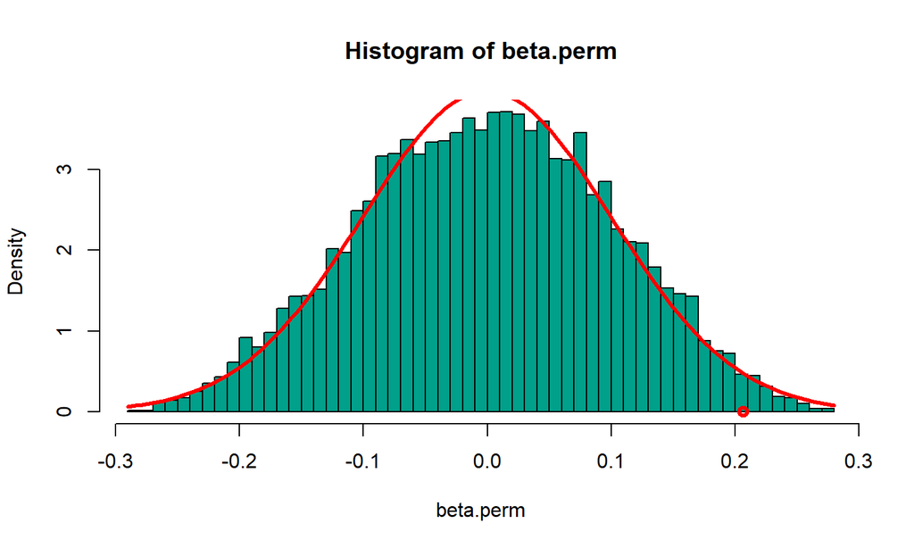

```r
hist(beta.perm,50,probability=TRUE,col=2)
curve(dnorm(x,mean(beta.perm),sd(beta.perm)),add=TRUE,col=1,lwd=3)
points(beta1,0,lwd=3,col=1)
```

## The (simple) linear model

We assume that the observed values are distributed around true values \(\beta_0 + \beta_1 X\) according to a Gaussian law:

\(Y=\textrm{linear part} + \textrm{normal error}\)

\(Y=\beta_0 + \beta_1 X + \varepsilon\)

**Assumptions of the linear model**

- the \(\boldsymbol{y_i=\beta_0 + \beta_1 x_i + \varepsilon_i}\) the relationship between \(X\) and the true (mean) \(Y\) is linear.
- the **observations** are **independent** each others ( knowing the value of the \(y_i\)observation does not help me to predict the value of \(y_{i + 1}\)). The random part is \(\varepsilon_i\), these are the independent terms.
- \(\boldsymbol{\varepsilon_i \sim N (0, \sigma ^ 2), \ \forall i=1, \ldots, n}\) errors have normal distribution with zero mean and common variance (homoschedasticity: same variance).

## Hypothesis testing

If these assumptions are true,

\(\hat{\beta_1} \sim N (\beta_1, \sigma ^ 2 / \sum (x_i- \bar{x}) ^ 2)\)

We calculate the test statistic:

\(t=\frac{\hat{\beta_1}}{std.dev\ \hat{\beta_1}}=\frac{\hat{\beta_1}}{\sqrt{\sum_{i=1} ^ n (y_i- \hat{y}_i) ^ 2 / \sum (x_i- \bar{x}) ^ 2 / (n-2)}}\)

If \(H_0: \beta_1=0\), \(t \sim t (n-2)\) is true

On `reaction` data and \(H_1: \beta_1 \neq 0\) (bilateral alternative)

```r
model=lm (Reaction.Time ~ Age, data=reaction)
summary(model) $ coefficients
```

```
##               Estimate Std. Error  t value   Pr(>|t|)
## (Intercept) 10.3013483 4.04406774 2.547274 0.03431997
## Age          0.2064719 0.07841111 2.633197 0.03002876
```

Similar result, but much more assumptions!

## Power is nothing without control

We don’t know if the data are genareted under \(H_0\) or under \(H_1\).

But we have a tool (the test) that

- if the data are generated **under \(H_0\)**: it suggests (wrong) \(H_1\) (i.e. \(p\leq \alpha\), type I error, false positive) with probability \(\alpha\). E.g. \(\alpha=.05\), low probability.
- if the data are generated **under \(H_1\)**: it suggests (correct) \(H_1\) (i.e. true positive) with probability larger than \(\alpha\).  
  This is the Power of a test. The Power is unknown, but we hope it is as high as possible.

## Properties

If the parametric assumptions are valid, the test guarantes

- the control of the type I error at the \(\alpha\) level,
- the maximum power (minimum error of type II \(\beta\)) among all the possible tests,
- asymptotic consistency (if they are under \(H_1\) rejection always for sufficiently large \(n\)).

The permutation tests usually have slightly less power and converge to the corresponding parametric tests, IF they exist.

## Confidence intervals

The parametric approach also allows us to calculate confidence intervals

```r
confint(model)
```

```
##                  2.5 %     97.5 %
## (Intercept) 0.97571138 19.6269853
## Age         0.02565557  0.3872883
```

In linear model: \[C.I.= [ \hat{\beta_1}-t_{1-\alpha/2} \hat{\sigma}/\sqrt{n}, \hat{\beta_1}+t_{1-\alpha/2} \hat{\sigma}/\sqrt{n}]\] (\(t_{1-\alpha/2}\) is the threshold given by a t-distribution with CDF equal to \(1-\alpha/2\) and d.f. \(n-1\))

Confidence intervals are constructed in such a way that in the long run they include the true value \(\beta_1\) with probability \(1-\alpha\) (e.g. 95 %).

Confidence intervals and hypothesis testing are closely related: if a confidence interval at level \(1-\alpha\) does not include the 0, the p-value that tests \(H_0:\ \beta_1 = 0\) will be \(p<\alpha\).

## A simulation to better understand

## A single fictitious dataset

We generate a fictitious datasets and see how the tests and confidence intervals behave.

- use the observed values for \(Age\) in the original dataset
- randomly generate values for \(Reaction.Time\).
- get the statistics (p-values, confidence interval)

## \(H_0\) is true (Type I error control)

There is no relationship between \(Age\) and \(Reaction.Time\).

then: \(Reaction.Time=\beta_0 + 0 Age + \varepsilon\)

\(\varepsilon\) can be assumed to be normal \(N(0,\sigma^2)\).

How to set \(\beta_0\) and \(\sigma^2\)?  
As reasonable values, we can use mean and variance calculated on the sample:

```r
m=mean(reaction$Reaction.Time)
s2=var(reaction$Reaction.Time)
s=sqrt(s2)
n=length(reaction$Age)
```

- \(\beta_0=\) 20.212
- \(\sigma^2=\) 36.3187511

```r
# generate random Reaction.Time
Reaction.Time=rnorm(n,m,s) # equivalent to m+rnorm(n,0,s)
#and fit the model
mod=lm(Reaction.Time~reaction$Age)
summary(mod)$coefficients
```

```
##                  Estimate Std. Error    t value    Pr(>|t|)
## (Intercept)  21.425641121 5.12806766 4.17811202 0.003087592
## reaction$Age  0.003815255 0.09942897 0.03837167 0.970331618
```

```r
confint(mod)
```

```
##                   2.5 %     97.5 %
## (Intercept)   9.6002959 33.2509863
## reaction$Age -0.2254684  0.2330989
```

## Many datasets

Now we generate many (e.g. 1000) datasets and we store the p-values.

```r
sim <- function(Age,n,m,s){
  Reaction.Time=rnorm(n,m,s)
  #get the p-value from the output
  summary(lm(Reaction.Time~Age))$coefficients["Age","Pr(>|t|)"]
}

p.sim=replicate(1000,sim(reaction$Age,n,m,s))
```

- What do I expect the distribution of these p-values to be?
- If I plot a histogram, what do I expect?
- What will be the proportion of p-values \(\leq 0.05\)?

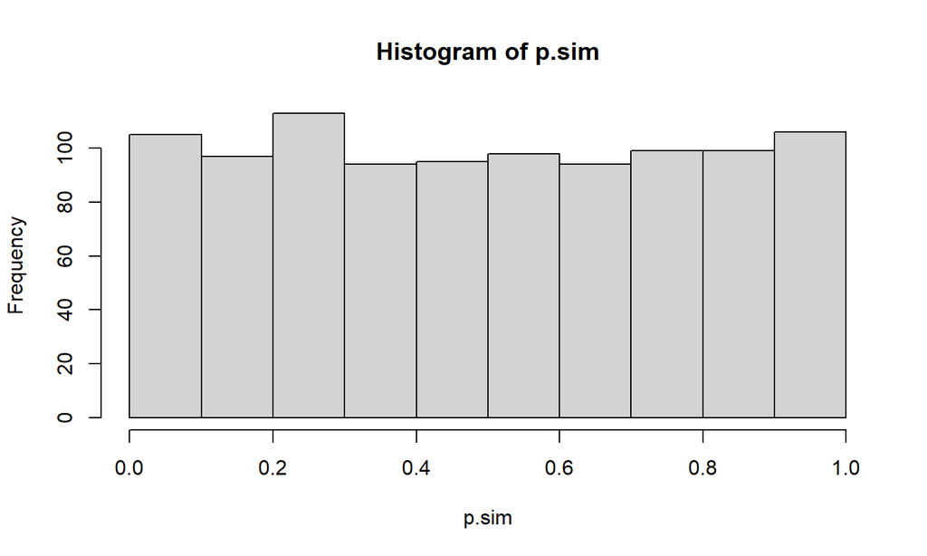

```r
hist(p.sim)
```

```r
#how many p<.05
sum(p.sim<.05)
```

```
## [1] 46
```

```r
#proportion of p<.05
mean(p.sim<.05)
```

```
## [1] 0.046
```

Now the (empirical) cumulative distribution

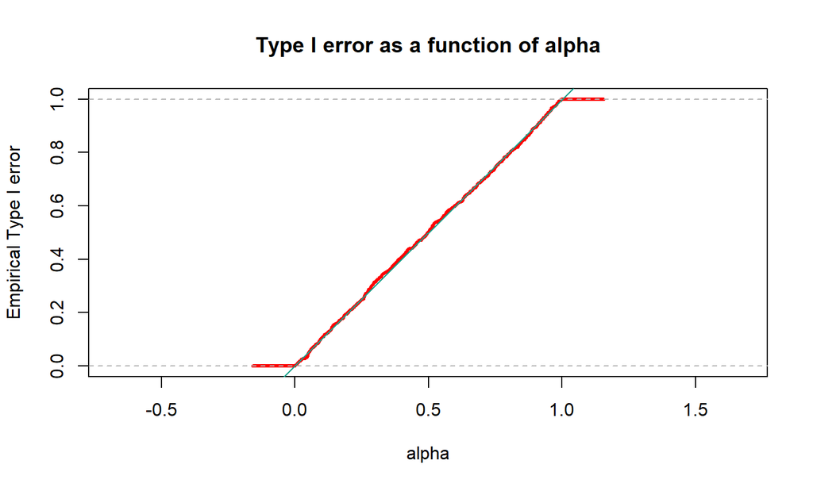

```r
plot(ecdf(p.sim),xlab="alpha",ylab="Empirical Type I error", col=1,main="Type I error as a function of alpha",lwd=3,asp=1)
abline(0,1,col=2)
```

For each value of the abscissa \(\alpha\) we see the empirical estimate of the type I error.

For any given \(\alpha\), the estimated proportion is around \(\alpha\) (and would converge to \(\alpha\) if we increases the number of replications)

Very good!! :)

## \(H_1\) is true (Power evaluation)

There is a relationship between \(Age\) and \(Reaction.Time\). I can use use the linear normal model with parameters - just an example - calculated on the sample.

```r
modelF=lm(Reaction.Time~Age,data=reaction)
coefficients(modelF)
```

```
## (Intercept)         Age
##  10.3013483   0.2064719
```

```r
beta0=coefficients(modelF)[1]
beta1=coefficients(modelF)[2]
```

```r
y_linear_part=beta0+beta1*reaction$Age
s=sd(residuals(modelF))
n=length(reaction$Age)

# generate random Reaction.Time
Reaction.Time=y_linear_part+rnorm(n,0,s)
#fit the model (estimate the parameters)
summary(lm(Reaction.Time~Age,data=reaction))$coefficients
```

```
##               Estimate Std. Error  t value   Pr(>|t|)
## (Intercept) 10.3013483 4.04406774 2.547274 0.03431997
## Age          0.2064719 0.07841111 2.633197 0.03002876
```

## Many datasets

Now we generate many (e.g. 1000) datasets and, for each, we store the p-value.

```r
p.sim=replicate(1000,sim(reaction$Age,n,y_linear_part,s))
```

- What do I expect the distribution of these p-values to be?
- If I plot a histogram, what do I expect?
- What will be the proportion of p-values \(\leq 0.05\)?

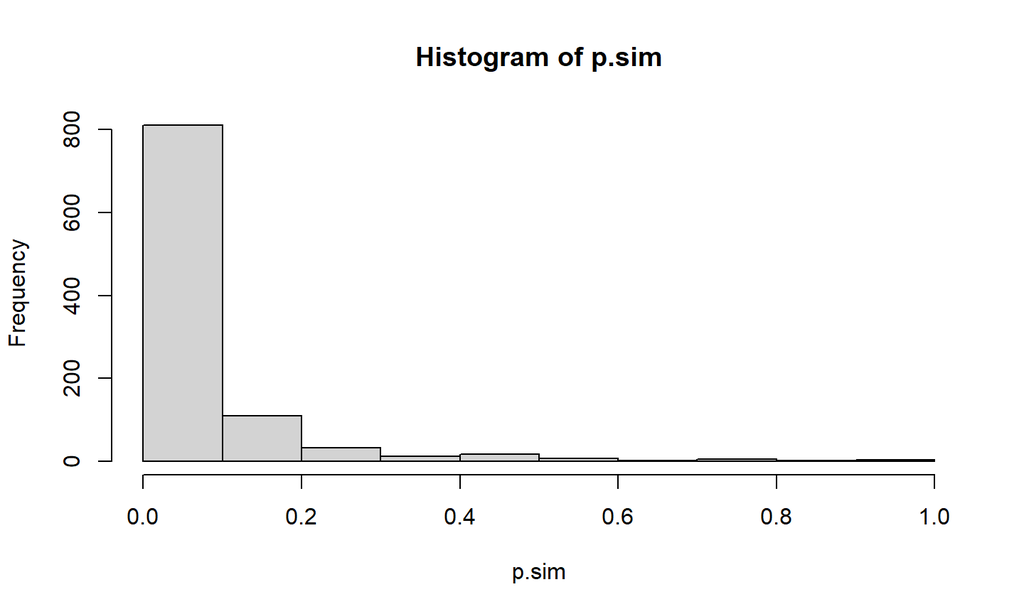

```r
hist(p.sim)
```

```r
#how many p<.05
sum(p.sim<.05)
```

```
## [1] 691
```

```r
#proportion of p<.05
mean(p.sim<.05)
```

```
## [1] 0.691
```

Now the (empirical) cumulative distribution

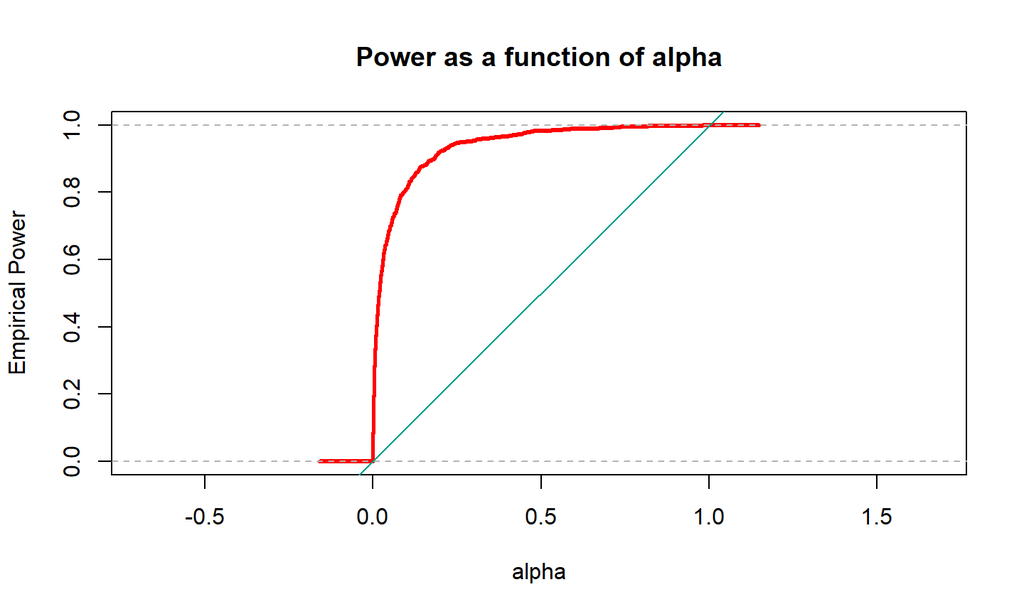

```r
plot(ecdf(p.sim),xlab="alpha",ylab="Empirical Power", col=1,main="Power as a function of alpha",lwd=3,asp=1)
abline(0,1,col=2)
```

For each value of the abscissa \(\alpha\) we see the empirical estimate of the Power.

For any given \(\alpha\), the estimated proportion greater than \(\alpha\), the test has power!

Very good!! :)

## Homework 1: Effect of measure quality (noise)

1. How do the Type I error varies as a function of the standard deviation of the normal errors?  
   Hint: Simulate with different sd (e.g. 2,4,8,16), store the proportion of rejections for \(\alpha=.05\), plot the sd vs rejections.
2. Same task, but under \(H_1\) (power study)

## Solution

```r
sim05 <- function(s,n,m){
  p.sim=replicate(1000,sim(reaction$Age,n,m,s))
  mean(p.sim<.05)
}
```

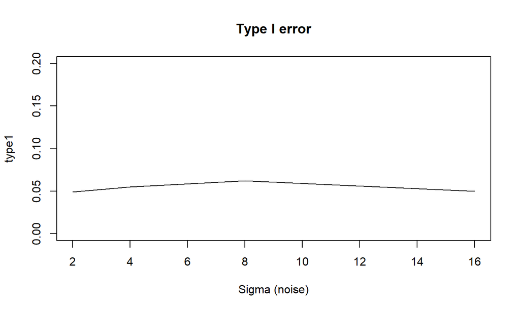

```r
s_values=c(2,4,8,16)
type1=sapply(s_values,sim05,n,m)
plot(s_values,type1,type="l",ylim=c(0,.2),main="Type I error",xlab="Sigma (noise)")
```

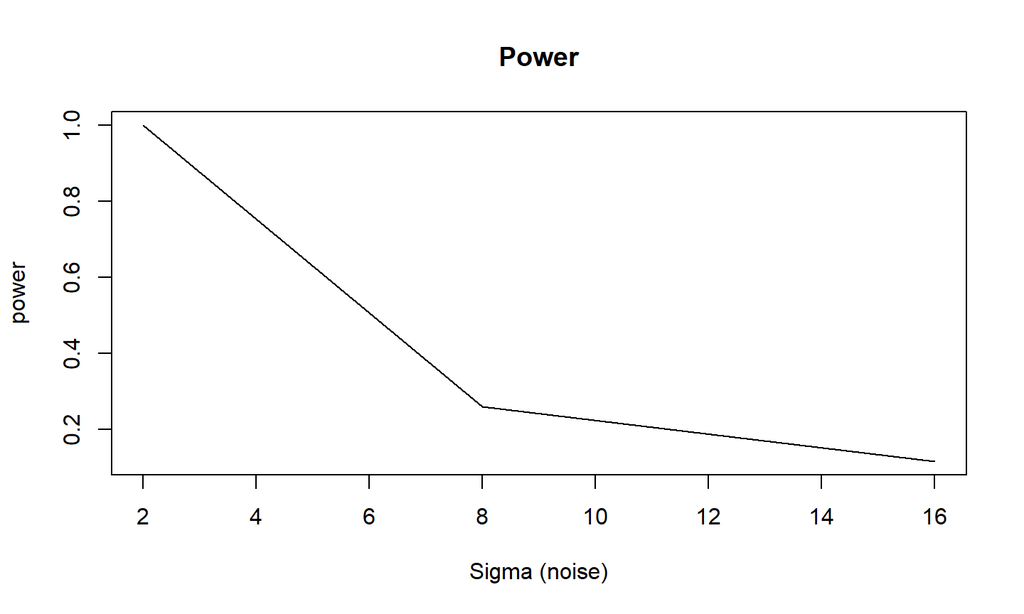

```r
power=sapply(s_values,sim05,n,y_linear_part)
plot(s_values,power,type="l",main="Power",xlab="Sigma (noise)")
```

## Homework 2: Effect of sample size

1. How does the type I error varies as a function of the sample size? (Same hint of homework 1, but here you sample `Age` `n` times and compute `y_linear_part` )
2. How does the power?

## Solution

```r
sim_n <- function(Age,n,betas,s){
  Agex <- sample(Age,n,replace = TRUE)
  while(length(unique(Agex))==1)
    Agex <- sample(Age,n,replace = TRUE)

  y_linear_part=betas[1]+betas[2]*Agex
  Reaction.Time <- rnorm(n,y_linear_part,s)
  #get the p-values from the output
  summary(lm(Reaction.Time~Agex))$coefficients["Agex","Pr(>|t|)"]
}

sim05_n <- function(n,betas,s){
  p.sim=replicate(1000,sim_n(reaction$Age,n,betas,s))
  mean(p.sim<.05)
}
```

### H0

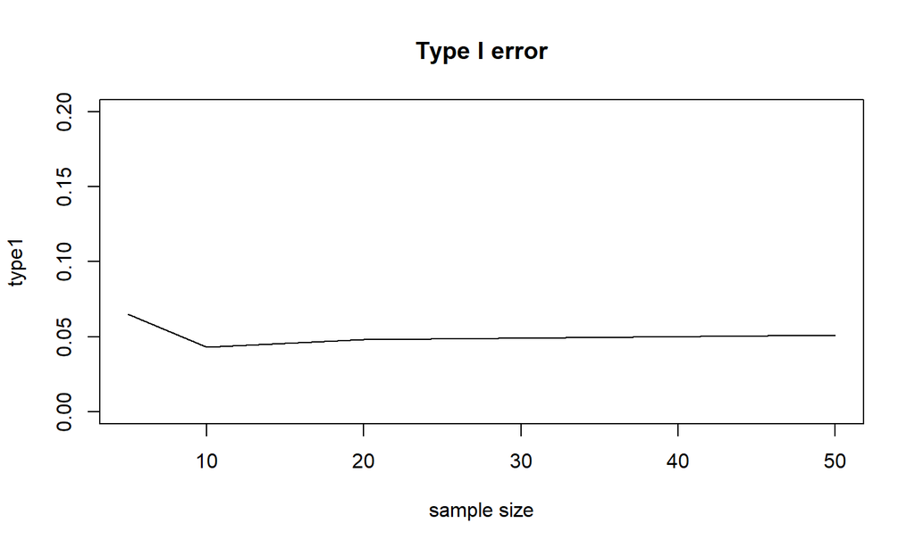

```r
betas=c(beta0,0)
ns=c(5,10,20,50)
type1=sapply(ns,sim05_n,betas,s)
plot(ns,type1,type="l",ylim=c(0,.2),main="Type I error",xlab="sample size")
```

### H1

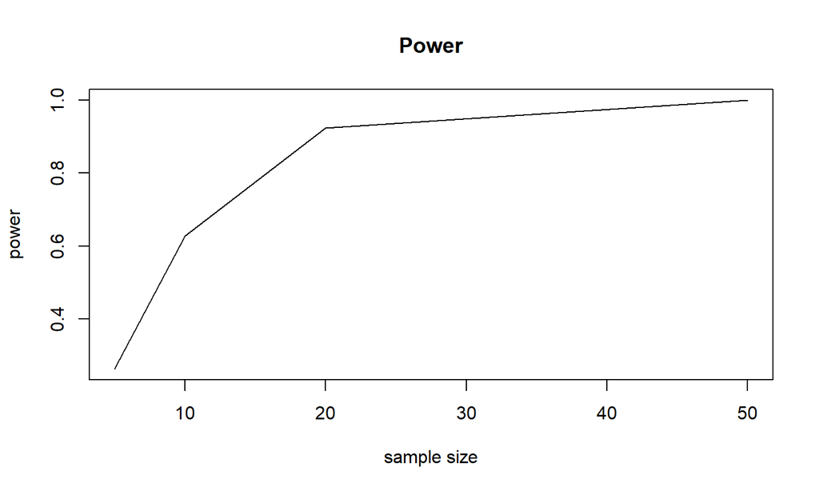

```r
betas=c(beta0,beta1)
power=sapply(ns,sim05_n,betas,s)
plot(ns,power,type="l",main="Power",xlab="sample size")
```

## Homework 3: Confidence intervals

Make similar evaluations of Homework 1 and 2 for confidence intervals:

- set \(\alpha=.05\),
- genate datasets, fit the models,
- Two quantities are of interest here:
  - counts of times the confidence interval contains the TRUE value \(\beta_1\)
  - length of the confidence interval

## Solution: Sigma (noise)

```r
sim <- function(Age,n,m,s){
  Reaction.Time=rnorm(n,m,s)
  #get the p-value from the output
  CI=confint(lm(Reaction.Time~Age))[2,]
  contained=all(sign(CI)==c(-1,1))
  CI_length=CI[2]-CI[1]
  names(CI_length)=NULL
  c(contained,CI_length)
}

sim05 <- function(s,n,m){
  p.sim=replicate(1000,sim(reaction$Age,n,m,s))
  rowMeans(p.sim)
}
```

### H0

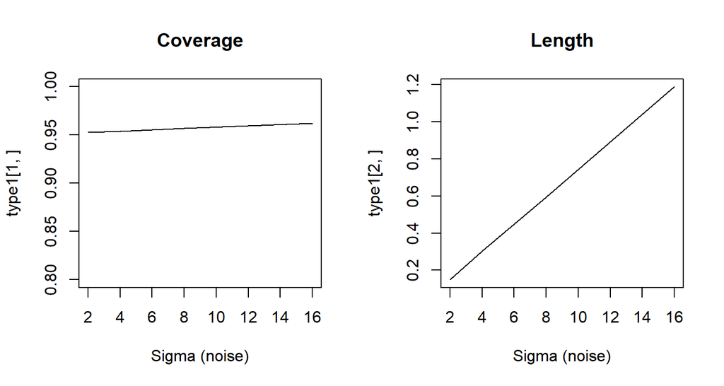

```r
s_values=c(2,4,8,16)
type1=sapply(s_values,sim05,n,m)
par(mfrow=c(1,2))
plot(s_values,type1[1,],type="l",ylim=c(.8,1),main="Coverage",xlab="Sigma (noise)")
plot(s_values,type1[2,],type="l",main="Length",xlab="Sigma (noise)")
```

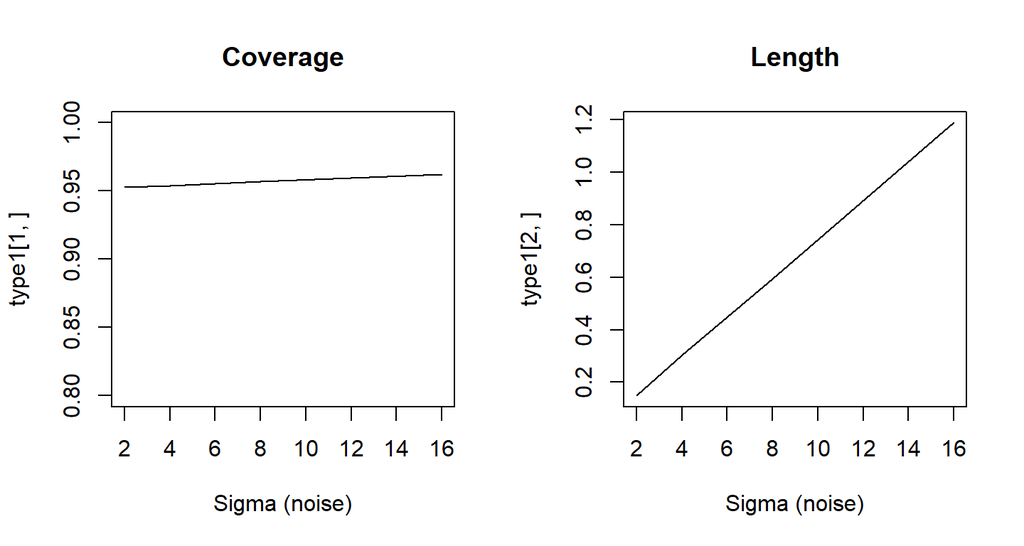

```r
power=sapply(s_values,sim05,n,y_linear_part)
par(mfrow=c(1,2))
plot(s_values,type1[1,],type="l",ylim=c(.8,1),main="Coverage",xlab="Sigma (noise)")
plot(s_values,type1[2,],type="l",main="Length",xlab="Sigma (noise)")
```

## Solution: sample size

```r
sim_n <- function(Age,n,betas,s){
  Agex <- sample(Age,n,replace = TRUE)
  while(length(unique(Agex))==1)
    Agex <- sample(Age,n,replace = TRUE)

  y_linear_part=betas[1]+betas[2]*Agex
  Reaction.Time <- rnorm(n,y_linear_part,s)
  CI=confint(lm(Reaction.Time~Agex))[2,]
  contained=all(sign(CI)==c(-1,1))
  CI_length=CI[2]-CI[1]
  names(CI_length)=NULL
  c(contained,CI_length)
}

sim05_n <- function(n,betas,s){
  p.sim=replicate(1000,sim_n(reaction$Age,n,betas,s))
  rowMeans(p.sim)
}
```

### H0

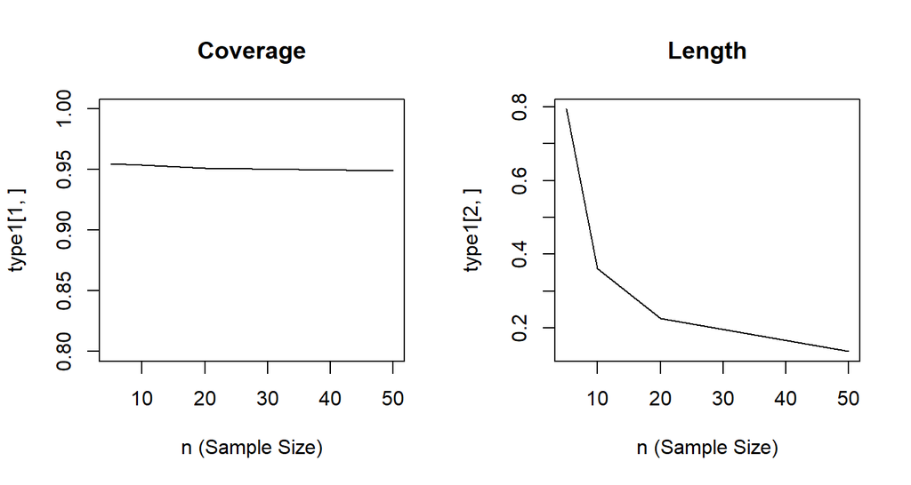

```r
betas=c(beta0,0)
ns=c(5,10,20,50)
type1=sapply(ns,sim05_n,betas,s)
par(mfrow=c(1,2))
plot(ns,type1[1,],type="l",ylim=c(.8,1),main="Coverage",xlab="n (Sample Size)")
plot(ns,type1[2,],type="l",main="Length",xlab="n (Sample Size)")
```

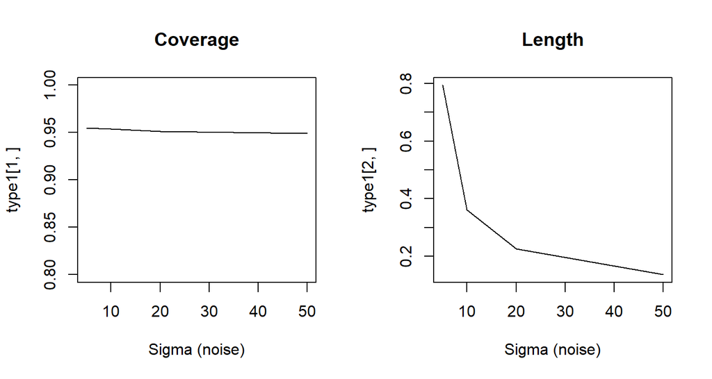

```r
betas=c(beta0,beta1)
power=sapply(ns,sim05_n,betas,s)
par(mfrow=c(1,2))
plot(ns,type1[1,],type="l",ylim=c(.8,1),main="Coverage",xlab="Sigma (noise)")
plot(ns,type1[2,],type="l",main="Length",xlab="Sigma (noise)")
```